# Spruce cone development Biological QA combined sets

Veronika Nordal & Nicolas Delhomme

2016-12-07

# 1 Setup

Set the working dir

```r
setwd("/mnt/picea/projects/spruce/onilsson/cone-development")
```

Load libraries

```r
suppressPackageStartupMessages(library(DESeq2))
suppressPackageStartupMessages(library(gplots))
suppressPackageStartupMessages(library(parallel))
suppressPackageStartupMessages(library(pander))
suppressPackageStartupMessages(library(RColorBrewer))
suppressPackageStartupMessages(library(scatterplot3d))
suppressPackageStartupMessages(library(vsn))
```

Source some helper functions

```r
source("~/Git/UPSCb/src/R/plot.multidensity.R")
```

Create a palette

```r
pal <- brewer.pal(8,"Dark2")
```

Register the default plot margin

```r
mar <- par("mar")
```

Read the sample information

```r
#  Read both sample files
samples <- read.csv("~/Git/UPSCb/projects/spruce-cone-development/doc/samples.csv",
                    row.names=1,as.is=TRUE)
samples.2 <- read.csv("~/Git/UPSCb/projects/spruce-cone-development/doc/samples_2.csv",
                    row.names=1,as.is=TRUE)

# Combine the sample files
samples <- rbind(samples,samples.2)
```

Read the data

```r
set1 <- read.csv("set1/analysis/HTSeq/raw-unormalised_tech-rep-combined_data.csv",row.names = 1)
# The same for set 2
set2 <- read.csv("set2/analysis/HTSeq/raw-unormalised-data.csv",row.names = 1)

# combine them by column
count.table <- cbind(set1,set2)
```

# 2 Data normalisation

For visualization, the data is submitted to a variance stabilization transformation using DESeq2. The dispersion is estimated independently of the sample tissue and replicate Create the dds object

```r
conditions <- colnames(count.table)
colnames(count.table) <- make.unique(colnames(count.table))
dds <- DESeqDataSetFromMatrix(
  countData = count.table,
  colData = data.frame(condition=conditions),
  design = ~ condition)
```

```r
dds <- estimateSizeFactors(dds)
sizes <- sizeFactors(dds)
names(sizes) <- colnames(count.table)
pander(sizes)
```

Table continues below

| P1387_101 | P1387_102 | P1387_103 | P1387_104 | P1387_105 | P1387_106 |
| --- | --- | --- | --- | --- | --- |
| 1.595 | 1.658 | 1.563 | 1.341 | 1.582 | 1.749 |

Table continues below

| P1387_107 | P1387_108 | P1387_109 | P1387_110 | P1387_111 | P1387_112 |
| --- | --- | --- | --- | --- | --- |
| 1.964 | 1.554 | 1.506 | 1.531 | 1.259 | 1.62 |

Table continues below

| P1387_113 | P1387_114 | P1387_115 | P1387_116 | P1387_117 | P1387_118 |
| --- | --- | --- | --- | --- | --- |
| 1.459 | 1.712 | 1.895 | 1.771 | 1.574 | 1.627 |

Table continues below

| P1387_119 | P1387_120 | P1387_121 | P1387_122 | P1387_123 | P1387_124 |
| --- | --- | --- | --- | --- | --- |
| 1.261 | 1.406 | 1.619 | 1.684 | 2.106 | 1.401 |

Table continues below

| P1387_125 | totRNA.10 | totRNA.14 | totRNA.15 | totRNA.16 | totRNA.17 |
| --- | --- | --- | --- | --- | --- |
| 1.443 | 0.4537 | 0.4126 | 0.7703 | 0.5036 | 0.6952 |

Table continues below

| totRNA.18 | totRNA.2 | totRNA.33 | totRNA.34 | totRNA.35 | totRNA.40 |
| --- | --- | --- | --- | --- | --- |
| 0.3437 | 0.472 | 0.3059 | 0.6303 | 1.268 | 0.2314 |

| totRNA.47 | totRNA.48 | totRNA.49 | totRNA.50 |
| --- | --- | --- | --- |
| 0.4281 | 0.5636 | 0.5102 | 0.3646 |

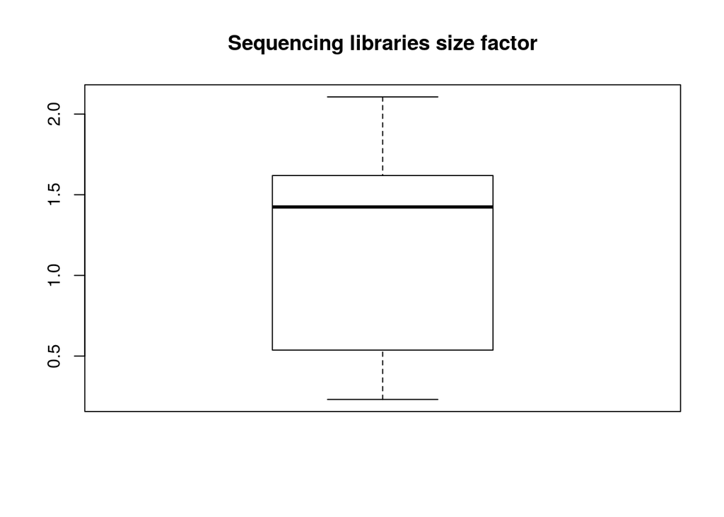

```r
boxplot(sizes, main="Sequencing libraries size factor")
```

Perform the VST

```r
colData(dds)$condition <- factor(colData(dds)$condition,
                                 levels=unique(conditions))
vsd <- varianceStabilizingTransformation(dds, blind=TRUE)
vst <- assay(vsd)
colnames(vst) <- colnames(count.table)
vst <- vst - min(vst)
dir.create("analysis/HTSeq",showWarnings = FALSE, recursive = TRUE)
write.csv(vst,"analysis/HTSeq/library-size-normalized_variance-stabilized_data.csv")
```

Validate the VST

Visualize the corrected mean - sd relationship.

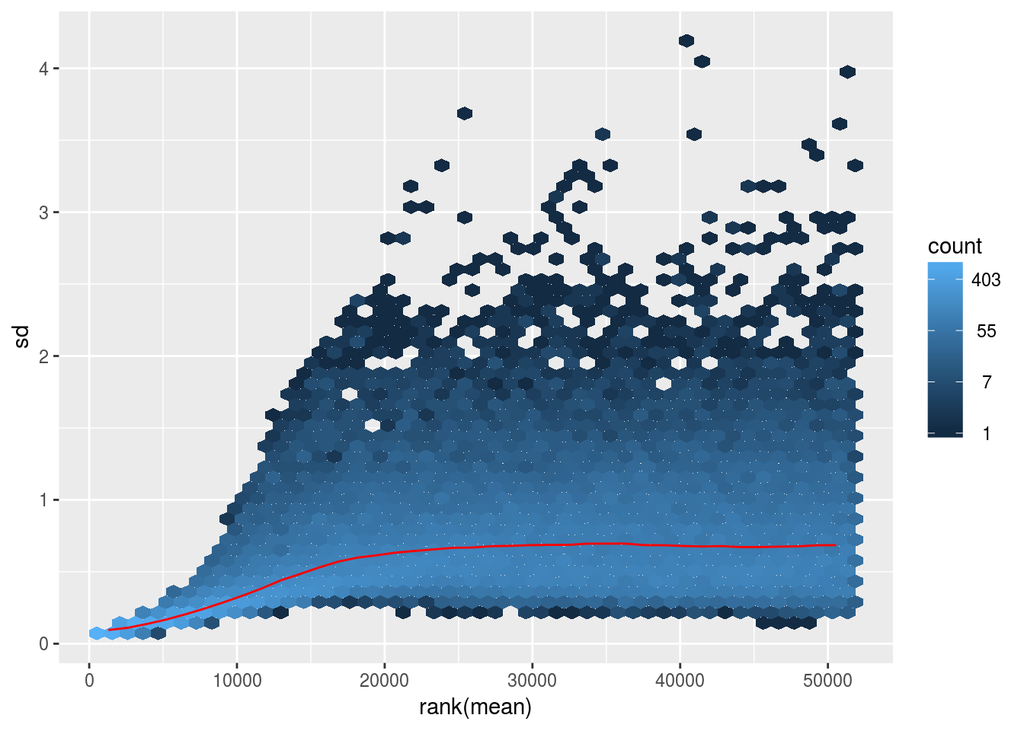

```r
meanSdPlot(vst[rowSums(count.table)>0,])
```

# 3 QC on the normalised data

## 3.1 PCA

First perform a Principal Component Analysis (PCA) of the data to do a quick quality assessment; i.e. replicate should cluster and the first 2-3 dimensions shouldbe explainable by biological means.

```r
pc <- prcomp(t(vst))
percent <- round(summary(pc)$importance[2,]*100)
```

Plot the PCA 3 first dimensions, They are colored by sample (using repeating colors)

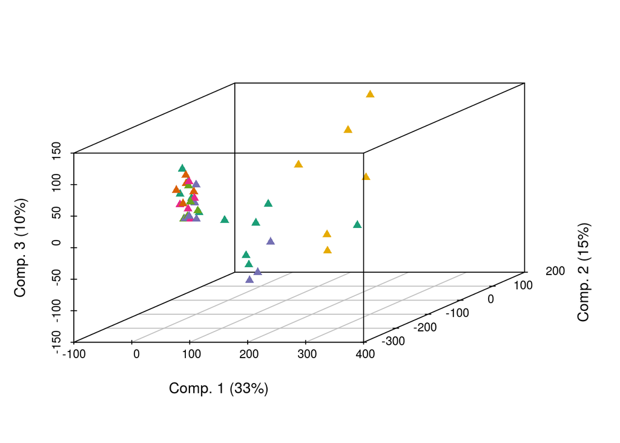

```r
mar=c(5.1,4.1,4.1,2.1)
scatterplot3d(pc$x[,1],
              pc$x[,2],
              pc$x[,3],
              xlab=paste("Comp. 1 (",percent[1],"%)",sep=""),
              ylab=paste("Comp. 2 (",percent[2],"%)",sep=""),
              zlab=paste("Comp. 3 (",percent[3],"%)",sep=""),
              color=pal[as.integer(factor(samples$Sample))],
              pch=17)
```

```r
par(mar=mar)
```

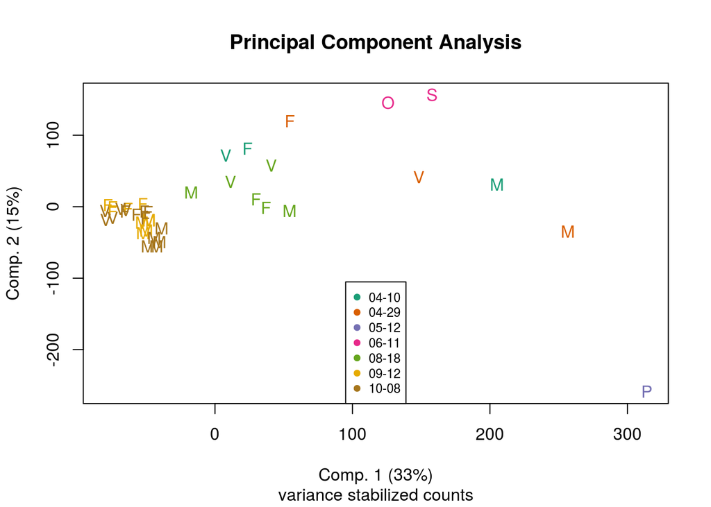

```r
plot(pc$x[,1],
     pc$x[,2],
     xlab=paste("Comp. 1 (",percent[1],"%)",sep=""),
     ylab=paste("Comp. 2 (",percent[2],"%)",sep=""),
     col=pal[as.integer(factor(samples$Sampling))],
     pch=samples$Sex,
     main="Principal Component Analysis",sub="variance stabilized counts")
legend("bottom", cex=0.75,
       col=pal[1:nlevels(factor(samples$Sampling))],
       pch=19,
       legend=levels(factor(samples$Sampling)))
```

And the 2nd and 3rd dims…

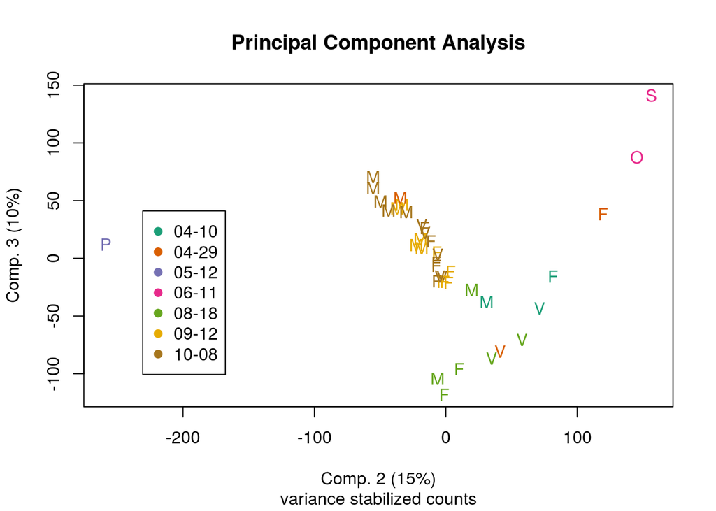

```r
plot(pc$x[,2],
     pc$x[,3],
     xlab=paste("Comp. 2 (",percent[2],"%)",sep=""),
     ylab=paste("Comp. 3 (",percent[3],"%)",sep=""),
     col=pal[as.integer(factor(samples$Sampling))],
     pch=samples$Sex,
     main="Principal Component Analysis",sub="variance stabilized counts")
legend("bottomleft", inset=0.1,
       col=pal[1:nlevels(factor(samples$Sampling))],
       pch=19,
       legend=levels(factor(samples$Sampling)))
```

## 3.2 Heatmap

The 1000 most variable genes are selected and plotted as a heatmap

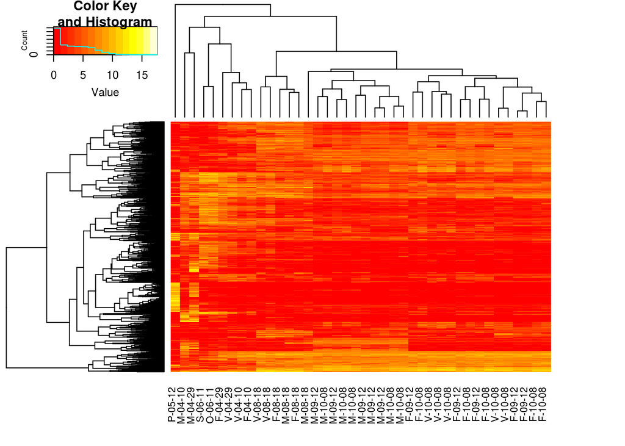

```r
dimnames(vst) <- dimnames(count.table)
sel <- order(apply(vst,1,sd),decreasing=TRUE)[1:1000]
heatmap.2(vst[sel,],labRow = NA,trace = "none",cexCol = 0.8, labCol=paste(samples$Sex,samples$Sampling,sep="-") )
```

# 4 Conclusion

Both sets are affected by the time of sampling and the tissue type. However, their relative importance is different. The first set is affected first by tissue type and then by sampling time, whereas the second is affected the other way around. Also there seem to be a batch effect, samples have been preped at different times and sequenced in different locations. This affects the clustering and we should keep it in mind for the DE (check if it affects the results).

# 5 Exporting the data

```r
colData(dds) <- cbind(colData(dds),samples[,c("Sex","Sampling","Sample")])
colData(dds)$Sex <- factor(colData(dds)$Sex)
colData(dds)$Sampling <- factor(colData(dds)$Sampling)
design(dds) <- ~Sampling * Sex
dir.create("analysis/DESeq2",showWarnings = FALSE)
save(dds,file = "analysis/DESeq2/deseq-sampling_time-tissue_type.rda")
```